# Computational Statistics 12.2: Factor Analysis

## Factor analysis

### Overview

This lesson introduces factor analysis.

### Objectives

After completing this module, students should be able to:

1. Explain the meaning of latent or underlying factors.
2. Calculate factors using R, and interpret the results.
3. Express factors in terms of variable or observation projections.

Note: this module assumes prior knowledge on covariance and correlation matrices. Need a refresher? Have a look at Module 7.1!

### Readings

NA

## Introduction to factor analysis

In the last learning module we described **factor analysis** as a method to find smaller set of underlying dimensions in a dataset with a large number of variables.

We are going to call this underlying dimensions, principal components or principal factors. And they are going to be modeled as simple linear functions of the variables in the data. The next equation is the basis of factor analysis:

$$C_{p} = \phi_{p1}x_{1} + \phi_{p2}x_{2} + \phi_{p3}x_{3} + ... + \phi_{pp}x_{p}$$

- $C_p$ is the $p$th principal component.
- The first component, $C_1$, is defined by the parameters $\{ \phi_{11}, \phi_{12},...\}$ (similar to how the $\beta_i$ parameters represented the slopes in a regression model).
- In this equation, just as each $x$ is a vector of $n$ observations, $C_p$ is also a vector of size $n$: the projection of the observations onto that component. Then, we are creating a new artificial variable from the values that we choose for $\{ \phi_{11}, \phi_{12},...\}$ and the values of $x$.
- The main differences between this type of linear models and the regression model are that:
  - There is no error term. The previous equation is not describing an stochastic relation, but a deterministic relation. As a result, there is no need to add a constant or intercept parameter.
  - The left hand side variable $C_{p}$ is not a random variable like $y$ is in the regression model. The values of $C_{p}$ can be perfectly explained by $x$.
- Note that potentially, with $p$ variables, we can create as many components. But, in general, we only use a few of them because the number of variables is already very large.
- What we want is to find is the values $\{ \phi_{p1}, \phi_{p2},...\}$ such that the variance of each $C_p$ is maximized. In that way, each $C_p$ will be able to represent the most possible variation in the data.
- Values $\{ \phi_{p1}, \phi_{p2},...\}$ are projections of the original variables onto $C_p$ – the larger $\phi_{p1}$ is, for instance, the larger the projection of $x_1$ on $C_p$ – ie, the more like $x_1$ $C_p$ is, or the more similar their directions in space are.
- Factor analysis actually long predates the era of big data and machine learning, and has a long history of different methods, most of which produce similar results.

**Example:** imagine that we have information on different cars: size, miles per hour, horsepower, number of cylinders, etc. We can use machine learning to find the underlying dimensions that describe *cars*. For instance, consider the underlying dimension *is it a truck?*, the parameters for this dimension should project the variables of the dataset in such a way that the values of trucks in that component are high.

The power of factor analysis relies on the fact that that we don’t have to manually specify what dimensions we want to create…but, that may also be its greatest weakness. If you think about it, the interpretation of the underlying components is subjective and arbitrary, and, they may simply reflect the *biases* of the statistician. I mean, what is a *truck*, but an artificial human categorization that the computer may not recognize as an individual category.

## Latent dimensions

Finding *latent dimensions* is basically fishing for vectors in a plane that explain the variation of the given data:

**When can we speculate that there is an underlying factor explaining multiple variables?**

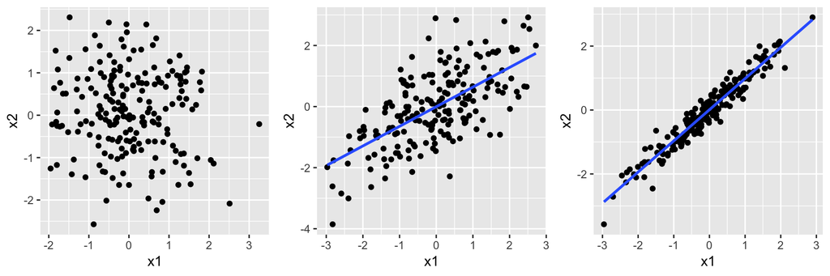

- Usually we can uncover common underlying factors when the variables in the database are correlated with each other. Thus, a single component can summarize the information of a large set of them. It will be hard to find a underlying factor in a database that include variables that represent perpendicular ideas.
- Look at the figure on the right: in this picture there is mainly a single underlying factor explaining the variation in the data, because $x_1$ and $x_2$ are basically just two measurements of a similar concept. For instance, $x_1$ and $x_2$ could be length of the right leg and length of the left leg, and the underlying factor is a person’s height. Note how the high correlation between $x_1$ and $x_2$ makes the process of identifying the latent dimension very easy.
- In the figure on the left, $x_1$ and $x_2$ are uncorrelated, and thus there are truly two different variables at play here. We’ll have a hard time trying to come up with a single line that describe the variations of both variables at the same time.
- The middle graph is an in-between scenario: there is a strong diagonal latent variable, but also a lot of variation around that diagonal line, which may constitute a second latent dimension. Remember that we can find a number of underlying dimensions as number of variables under analysis.

### Space and latent dimensions

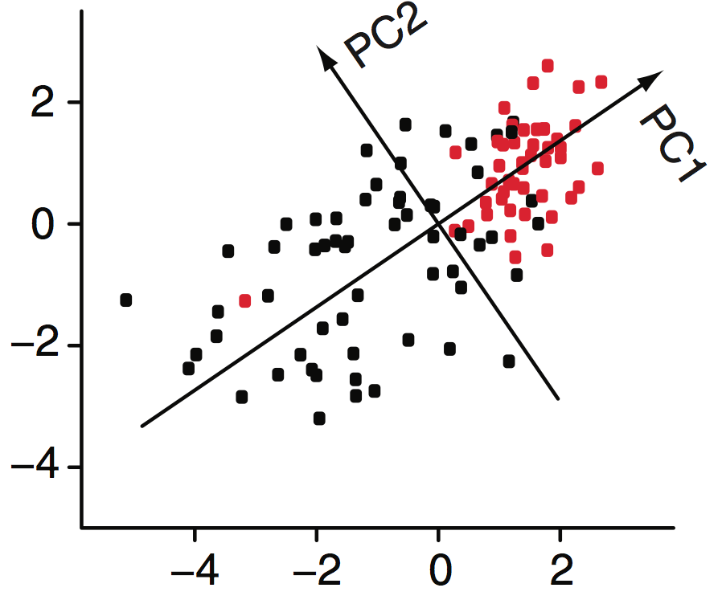

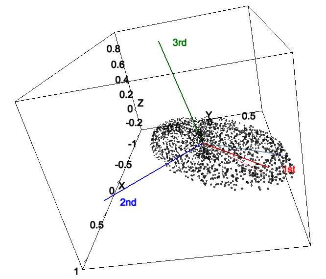

**Two-dimensional space:**

- As previously mentioned, with 2 variables there can be at most two underlying dimensions.
- In factor analysis, the main underlying factor is called the first *principal component*, which is along the main axis of the data.
- The second principal component is perpendicular to this.
- The longer vector (arrow) in the picture of the left represents the principal component and the smaller and perpendicular one the second component.
- Note that if the goal is to summarize the variability of the data with a single component, the principal component is a better choice than the second component.

**Three-dimensional space:**

- We can extend this type of analysis to three variables. See the graph on the right.
- The pattern is the same: the first (principal) component is along the longest axis of the data (red), the second component is the second-longest axis perpendicular to the first (blue), and so on. (You can interact with this graph to get a better visual sense [here](http://www.joyofdata.de/public/pca-3d/).)

**Higher Order**

- Unfortunately we cannot visually represent the case of $p = 4$ as we are trapped in a 3-dimensional reality.
- Because each consecutive component is shorter than the previous one and account for less of the variation in the data, we usually only work with the first few.

### Latent dimensions interpretation

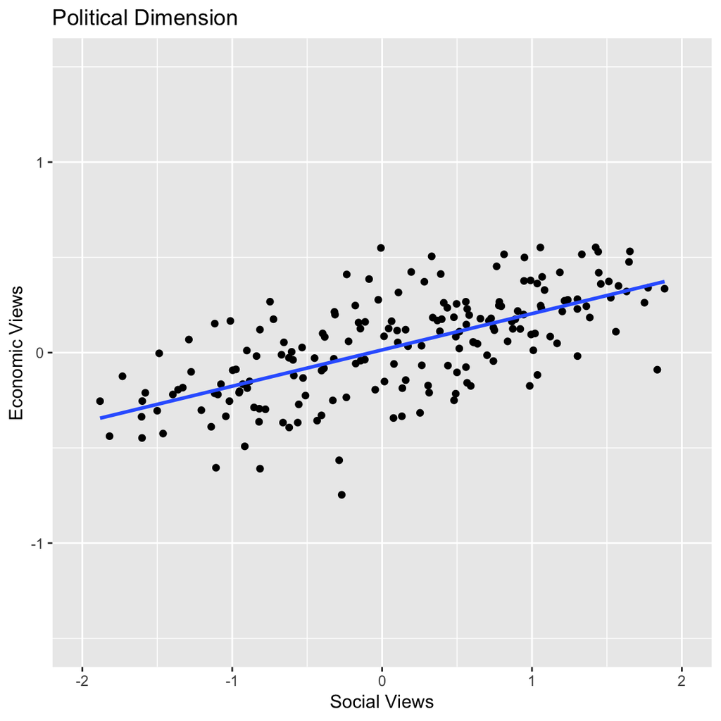

- Consider the previous graph. The $x$ axis represent the social views and the $y$ axis the economic views of set of individuals. We are using machine learning to discover the underlying *political* dimension.
- Although there is clearly an underlying factor that explains much of the variation in the data, that dimension is fairly similar to $x$, and fairly orthogonal (perpendicular) to $y$. That is, the projection of the principal component on $x$ is large, while the projection on $y$ is small.
- In other words, using this results we would conclude that the *political* dimension is mainly determined by one’s social views, and only slightly affected by one’s economic views.
- While there is still basically just one main political dimension (the first principal component, the blue line), that main political dimension isn’t all that different from the $x$ variable, and the scores individuals would have on $x$ would be similar to the scores they have on the first component.
- So when we find an underlying dimension we can ask:
  - First, how do the observations project onto the components? That is, what are the individual scores not in terms of the original variables, but in terms of the new, transformed dimensions.
  - Second, how do the original variables project onto the components? That is, (roughly speaking) what proportion of each of the original variables make the new one? Is it 50% $x$ and 30% $y$ and 20% $z$ (ie, is it pointing mainly in the $x$ direction), or is it 10% $x$, 10% $y$, and 80% $z$ (ie, pointing almost entirely in the $z$ direction, and not very different from $z$)? Etc.

To understand the system we are examining, we are mainly interested in answering the second question: how do the new artificial variables explain and relate to the original ones?

**Example:** IQ is perhaps the most famous factor analysis, which takes scores on a set of different types of mental tests, and finds that they are all strongly correlated with each other and thus can be “explained” by a single underlying factor; when you take an IQ test, you actually get scores on all these separate variables, and then your IQ is the underlying factor that combines these scores into one.

## Estimation

The most common method of estimation of principal components is using the covariance matrix of the variables: That is, if $x_{1}$ and $x_{2}$ are highly correlated their covariance will also be relatively high. Then, since an observation’s scores $x_{1}$ and $x_{2}$ are very similar, we would likewise expect $x_{1}$ and $x_{2}$ to have similar scores on any given component.

- The **covariance matrix** presents us with all the covariances between every pair of variables, and what we want to do is use this matrix to find which variables are jointly both highly correlated, and have a high degree of variance. Similar to the correlation matrix, you can find the compute the covariance matrix in `R` using the `cov` function.
- One flaw using covariances is its value depends on the units in which the variables are measured. Measured in $\$10K$ units, the variance of incomes in the US is one thing, but measured in $\$1$ units, the variance is much larger. So generally we need to standardize (rescale) everything to have a mean of 0 and standard deviation of 1 before we use them. In order do to so, we simply subtract the mean from each variable and divide by the standard deviation:

$$\hat{x} = \dfrac{x - \bar{x}}{sd_{x}}$$

where $\bar{x}$ is the mean of $x$ and $sd_{x}$ the standard deviation. In `R` You can quickly scale a variable or set of variables using the `scale` function.

- Using the covariance matrix of the standardized variables, we then need to find the component with the highest variance. We can do this by using the **eigenvectors** of the covariance matrix. Explaining this in perfect detail would take us too far afield, but the eigenvectors of a matrix are much like the principal components of a data set.
- An eigenvector is defined as a vector such that, when multiplied by its associated matrix, gives as a result the exact same vector, except stretched or shrunk by some constants known as the **eigenvalue**. This equation defines an eigenvector,

$$M v_{p} = \lambda_{p}v_{p}$$

- A matrix with dimension ($p \times p$, $p$ rows and $p$ columns) has exactly $p$ eigenvectors.
- Each eigenvector is of length $p$.
- And crucially, there are no other vectors besides the eigenvectors that, when multiplied by M, give you a vector pointing in the same direction; every other vector ends up pointing in some different direction after multiplying by M.

So why do we care about eigenvectors? Like principal components, eigenvectors represent a version of the data that contains much of the information in the original data, but in a smaller form.

Every squared matrix $M$ has $p$ eigenvectors and $p$ eigenvalues associated with it: $\{v_{1}, \lambda_{1}\}, \{v_{2}, \lambda_{2}\}, \{v_{3}, \lambda_{3}\}...$. We can order them by the size of $\lambda_{p}$: the eigenvector with the largest eigenvalue $\lambda_{p}$ is the first eigenvector (and thus the principal component).

## Estimation Procedure

In summary, the classic procedure for finding the principal components (i.e., the values $\{\phi_{p1}, \phi_{p2},...\}$ and the projections $C_{1},C_{2},...$) is:

1. Standardize the variables.
2. Create a covariance matrix.
3. Find the eigenvectors and eigenvalues for that matrix.
4. Sort them by magnitude.
5. Choose how many of them we want to keep and then create the components using linear equations where the parameters are the sorted eigenvalues.

To put this in more concrete terms, we’ll go over an example. First I’ll simply use a built-in function to compute the principal components and then I’ll go over this steps manually.

### Example 1/5

For this example we’ll use the `psych` package in `R`, a package of useful functions and example datasets for analyzing psychological data.

- In the package, we can find the “Motivational State Questionnaire” dataset, a set of 3,896 individual responses to a battery of mood questions.
- The subset we’re interested in here is 71 questions that were asked of each subject about their mood at the time of the survey: how happy, anxious, alert, sleepy, surprised, etc, etc,
- They were measured at that moment on a 0-3 scale.

The substantive question is, there are a lot of mood questions out there, but do people really have 71 different moods at any given time? Or are there a few underlying emotional factors that explain most of how you feel at any given moment, and the myriad specific moods are just different ways of measuring the simpler, underlying factors? For instance, in the study that collected these data, the researchers started with the common assumption that one of the dominant underlying factors is whether you are happy or sad at any given moment; this level of happiness vs sadness shapes many of the other moods people report at any given moment, and is sort of like a basic thermometer reading for anyone at any time.

### Example 2/5

Let’s get the data, clean it up a bit and take a quick look:

```r
# install.package("psych")
library(psych)
data(msq) # Loading “Motivational State Questionnaire” dataset
msq1 <- msq[, 2:72] #Getting only the 71 variables of interest
msq1[msq1=="9"] = NA  # 9 is the code for NA in this dataset
msq1 <- data.frame(msq1) # Creating dataset
msq2 <- na.omit(msq1)   # Omitting observations with missing data
names(msq2) #Checking the variables names
```

```
##  [1] "afraid"       "alert"        "angry"        "anxious"
##  [5] "aroused"      "ashamed"      "astonished"   "at.ease"
##  [9] "at.rest"      "attentive"    "blue"         "bored"
## [13] "calm"         "cheerful"     "clutched.up"  "confident"
## [17] "content"      "delighted"    "depressed"    "determined"
## [21] "distressed"   "drowsy"       "dull"         "elated"
## [25] "energetic"    "enthusiastic" "excited"      "fearful"
## [29] "frustrated"   "full.of.pep"  "gloomy"       "grouchy"
## [33] "guilty"       "happy"        "hostile"      "idle"
## [37] "inactive"     "inspired"     "intense"      "interested"
## [41] "irritable"    "jittery"      "lively"       "lonely"
## [45] "nervous"      "placid"       "pleased"      "proud"
## [49] "quiescent"    "quiet"        "relaxed"      "sad"
## [53] "satisfied"    "scared"       "serene"       "sleepy"
## [57] "sluggish"     "sociable"     "sorry"        "still"
## [61] "strong"       "surprised"    "tense"        "tired"
## [65] "tranquil"     "unhappy"      "upset"        "vigorous"
## [69] "wakeful"      "warmhearted"  "wide.awake"
```

```r
msq2 <- scale(msq2) # standardizing variables
dim(msq2) # Dataset dimensions (n, k)
```

```
## [1] 1747   71
```

That’s a lot of variables! Imagine running regressions by adding the variables one by one, it would take years for us to finish.

### Example 3/5

The `psych` package includes a robust factor analysis function, `fa()`. It actually does much more than simply finding the eigenvectors of the covariance matrix. One of the most important tweaks is that it rotates the principal components a little bit to nudge things so that each component use fewer variables. Without the rotation, we might get for the first principal component that it is 40% $x_1$, 30% $x_2$, 20% $x_3$, and 10% $x_4$; after the rotation, we might get 60% $x_1$ and 40% $x_2$, and none of the rest. But as we will see, often this extra rotation doesn’t make much difference, and ultimately we end up with the same eigenvectors.

```r
# You may need to install the package GPArotation
# install.package("GPArotation")
fact <- fa(msq2, nfactors = 2)
fact1 <- fact$loading[,1]
```

Here we are only calculating the first two factors for the sake of simplicity. The second line extracts the *loadings*, this are the projections of the variables onto the factors, i.e. the component parameters $\{\phi_{p1}, \phi_{p2},...\}$.

- **These are essential for interpreting the factors**: if the first factor loads highly positive on all the *happy* variables and highly negative on all the *unhappy* variables, then we know this factor is probably the happiness-unhappiness underlying dimension. But if it loads on some other set of variables, maybe some other underlying factor explains the biggest variance in mood.

### Example 4/5

The best way to read the factor, then, is to look not at the loadings as ordered by the variables (i.e., $\{\phi_{p1}, \phi_{p2},...\}$), but rather to order them from largest to smallest, so we can see what variables load most positively, and what variables load most negatively: What are the two poles along which the first latent dimension varies?

```r
fact1[order(fact1)]
```

```
##     sluggish        tired         dull       gloomy       sleepy
##  -0.57105799  -0.54881685  -0.54750768  -0.53205954  -0.50569655
##      grouchy       drowsy    depressed      unhappy    irritable
##  -0.50203289  -0.49831594  -0.49528362  -0.48878774  -0.47579067
##     inactive         blue          sad        upset   frustrated
##  -0.46837928  -0.46244573  -0.41256029  -0.41080632  -0.40251644
##        bored      hostile   distressed       lonely        angry
##  -0.37434355  -0.35435492  -0.35003093  -0.34831253  -0.32835989
##        quiet         idle        sorry      ashamed      fearful
##  -0.29948657  -0.27307778  -0.26551905  -0.23102291  -0.20674325
##        tense       afraid  clutched.up       guilty       scared
##  -0.20531701  -0.19916658  -0.19462196  -0.17660533  -0.17244643
##        still      nervous       placid      anxious    quiescent
##  -0.14494122  -0.10041209  -0.04945854   0.01036319   0.07525211
##      jittery   astonished     tranquil    surprised      intense
##   0.09560217   0.14366556   0.17480685   0.22752845   0.23026932
##       serene         calm      at.rest      relaxed      at.ease
##   0.24368851   0.26822107   0.30673400   0.38998166   0.47890593
##   determined       strong     inspired        proud      aroused
##   0.49890726   0.54461269   0.56684424   0.57895328   0.58282944
##   interested  warmhearted    confident    delighted     vigorous
##   0.59668718   0.61225943   0.62979990   0.64521495   0.64831274
##      wakeful    attentive    satisfied       elated   wide.awake
##   0.65002080   0.66440296   0.66796561   0.66890261   0.67136906
##     sociable      content        alert      excited      pleased
##   0.67158295   0.67492386   0.68666737   0.69832570   0.72470873
## enthusiastic  full.of.pep        happy       lively    energetic
##   0.75267586   0.77269967   0.77920857   0.78151569   0.78457320
##     cheerful
##   0.78675772
```

This is a lot to look at, but we can immediately tell what variables go into the first factor by looking at the lowest- and highest-scoring variables (the sign, ie, which direction is positive vs negative, is arbitrary and meaningless).

We find that while one end is happy; enthusiastic, cheerful, full.of.pep, lively, and energetic, the other side is not unhappy so much as sluggish, tired, dull, sleepy, etc. The most important factor underlying all these 71 moods is not happy vs unhappy, but more like energetic (and happy) vs tired, sleepy, and depressed. An important discovery! or is it? I’m not a psychologist, I don’t have the expertise to say what moods are associated with sadness, happiness, etc. And more fundamentally, in the end, the idea of *happiness* is human concept. Maybe full of energy and enthusiastic is not the same as *happy*, and we are just projecting our humans concepts into the data. I mean, I think you can be tired and happy at the same time, right?

### Example 5/5

So, what is the second factor? Is it happy/unhappy? Or some other dimension of mood? We can again examine it from the `fa()` output:

```r
fact2 <- fact$loading[,2]
fact2[order(fact2)]
```

```
##         calm      relaxed      at.ease     tranquil       serene
## -0.352885876 -0.329328504 -0.314019286 -0.296146699 -0.239425721
##      at.rest        still     inactive       placid         idle
## -0.220366409 -0.210805035 -0.181192225 -0.158556289 -0.130717864
##      content        tired       drowsy       sleepy    satisfied
## -0.092566444 -0.085640657 -0.084743296 -0.074466172 -0.052861670
##     sluggish        quiet        bored    quiescent         dull
## -0.051250126 -0.047187091 -0.037158459  0.008404442  0.017418666
##  warmhearted        happy    confident      pleased     sociable
##  0.030302370  0.049778277  0.062769206  0.103344356  0.105867790
##    delighted     cheerful        proud   interested      wakeful
##  0.144332820  0.145129497  0.191750307  0.205150300  0.236644249
## enthusiastic    attentive   wide.awake       strong        alert
##  0.245216122  0.251307405  0.267979328  0.275439171  0.276002665
##       elated  full.of.pep       lively    energetic     vigorous
##  0.277534264  0.302719139  0.306414361  0.334074266  0.354623629
##      aroused      grouchy    surprised      excited     inspired
##  0.374395194  0.383309096  0.384160442  0.387856349  0.389399539
##       lonely   astonished    irritable   determined       gloomy
##  0.413086287  0.430430321  0.434064713  0.440353948  0.446182126
##      hostile         blue      jittery    depressed       guilty
##  0.450331361  0.473217869  0.482896170  0.487026145  0.490809488
##      unhappy      ashamed        sorry          sad      intense
##  0.515707520  0.527920666  0.543121600  0.549980128  0.555921589
##  clutched.up        angry      anxious       afraid      fearful
##  0.573135634  0.575964542  0.585729159  0.598757261  0.599046272
##        upset       scared   frustrated      nervous   distressed
##  0.602792835  0.616661476  0.619454282  0.629479344  0.637585044
##        tense
##  0.674806887
```

Now we see a second dimension that is interestingly different from the first: not energetic vs sleepy, but relaxed and calm versus tense and frustrated. Here too, the factor is both not quite what we expected, but at the same time familiar and plausible. I mean, this feel a bit like cheating, the analysis can produce any two set of factors, and I bet you there are very creative people that can come up with explanations as to why they are *plausible*.

Within the `fa()` output we also get the projections of the individual observations onto each of these dimensions (ie, how energetic-vs-tired someone seems to be, and how calm-vs-tense they seem to be, and so on for all the other factors we might estimate), and a large number of other diagnostics and outputs (too many to show here!). There’s a whole new world to explore in factor analysis.

### Other estimation methods

For instance, here are two other methods for estimating principal components, both built into the base `R` package, but using different approaches. The first uses singular value decomposition (another unsupervised approach similar to factor analysis), and the second uses the covariance/eigenvector approach.

```r
# prcomp method using SVD
pcaA <- prcomp(msq2)
pcaA1 <- pcaA$rotation[,1]

# Princomp method using eigen of cov
pcaB <- princomp(msq2)
pcaB1 <- pcaB$loadings[,1]
```

Finally, let’s do it manually ourselves using `cov()` to estimate the covariance matrix and `eigen()` to get the eigenvectors:

```r
# 2. Compute covariance matrix
covm <- cov(msq2)

# 3. Compute eigenvectors
eigenm <- eigen(covm)

# 4. First loadings
eigen1 <- eigenm$vectors[,1]
```

How similar are these methods?

```r
f1mat <- cbind(fact1,pcaA1,pcaB1,eigen1)
cor(f1mat)
```

```
##             fact1      pcaA1      pcaB1     eigen1
## fact1   1.0000000  0.9999656 -0.9999656  0.9999656
## pcaA1   0.9999656  1.0000000 -1.0000000  1.0000000
## pcaB1  -0.9999656 -1.0000000  1.0000000 -1.0000000
## eigen1  0.9999656  1.0000000 -1.0000000  1.0000000
```

Essentially identical, with `fa()` being slightly different due to the rotation – but not very much different.

## How many factors to keep?

Since factor analysis theoretically can produces as many factors as there were variables originally ($p$), but one of the purposes of factor analysis is to reduce a high number of variables in the dataset to a smaller set of factors, one might naturally wonder how many factors do we have to keep? Can a 100-variable dataset be reduced to just three factors that explain most of the variation? How do we know how many to keep?

It turns out this question is a vexed and ongoing one, and has been for decades. Ideally we would want a nice statistical test to tell us that the first k factors are statistically significant in some sense, and the remaining ones are just picking up on random noise. But despite many suggested such tests, the community has not really settled on a single best test.

Perhaps one of the oldest and most established methods is looking at the eigenvalues, which in a sense determine the relative importance of each of the factors: the bigger the eigenvalue, the more of the variation in the original data that eigenvector/factor explains.

### Scree plot

One common way of examining these values is to plot them, ordered by size, in something called a “scree plot” (because it looks like the scree on the side of a mountain). All of our estimation methods above include the values as well as the factors, and here is a simple scree plot of them from our manual eigenvector method.

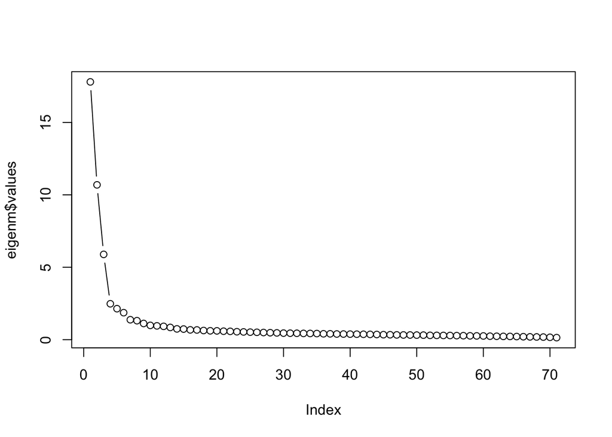

```r
plot(eigenm$values, type = "b")
```

### Cumulative variance

One final way to see this is the plot the proportion of the total variance in the data explained by the factors as you add them together. Since the eigenvalues are equivalent to the amount of variance each component explains in the original data, we can just do the same plot as before, but use the `cumsum` function to plot the cumulative amount and normalize it by dividing by the total.

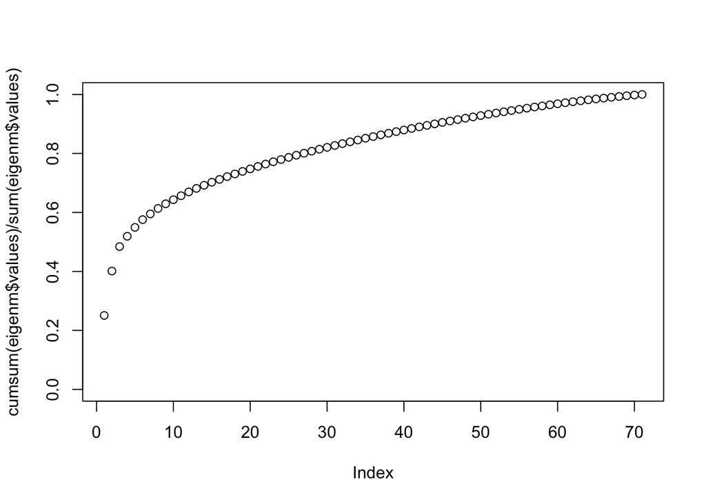

```r
plot(cumsum(eigenm$values)/sum(eigenm$values), ylim=c(0,1))
```

## Creating a quality index (Example)

One of the benefits of factor analysis is its ability to summarize complex information from a large set of variables into a smaller number of variables. In practice it can be used even if the number of variables is small to construct indices to facilitate decision making. For example, in the present, one of the biggest challenges in the Healthcare industry is to summarize complex information for patients. In this example we’ll go over a dataset that I’m currently working on - you can find this data in *Blackboard > Course Resources > Data* -

In the `qualityData` databse we have information on several medical measures of quality of care of dialysis centers in the states of New England from 2012 to 2016. The goal is to use this complex medical variables and come up with a single number that let patients know if the care at a given facility is “good” or “bad”. The following variables are available for us:

- `str` Facility’s Standardized Transfusion Rate.
- `shr` Facility’s Standardized Hospitalization Rate.
- `smr` Facility’s Standardized Mortality Rate.
- `avf` Percent of patients with arterial venous fistula (higher the better)
- `ktv` Percent of patients with Kt / Volume > 1.2, this is a measure of the adequacy of the dialysis.
- `c90` Percent of patients with a catheter for more than 90 days.
- `hca` Percent of patients with hypercalcemia.

As you can see, they are not that *many*; but the meaning of this measures can be a bit complex if you are not a doctor. Presenting all of this statistics to a patient may cause decision paralysis or they may simply ignore all this numbers and choose the closest facility to their residence. Instead, we’ll use factor analysis to come up with a single quality index. Note that this *minimalistic* approach to presenting choices can be applied to many other contexts.

### Scaling the data

Let’s load the data and take a quick look at the descriptive statistics

```r
dataRDirectory <- "/Users/CCD-MAC/Documents/Dropbox NEU/Dropbox/NEU/Thesis/Paper Dialysis/Data/Clean Data/R/"
dialysis <- read.csv(file = paste(dataRDirectory, "data.csv", sep = ""), stringsAsFactors = F)
qualityData <- dialysis[,c("str", "shr","smr",
                          "avf", "ktv", "c90","hca")]

library(stargazer)
stargazer(qualityData, summary = T, type = "html")
```

| Statistic | N | Mean | St. Dev. | Min | Pctl(25) | Pctl(75) | Max |
| --- | --- | --- | --- | --- | --- | --- | --- |
| str | 783 | 0.875 | 0.492 | 0.000 | 0.565 | 1.100 | 3.400 |
| shr | 840 | 0.946 | 0.244 | 0.110 | 0.790 | 1.090 | 2.190 |
| smr | 840 | 0.900 | 0.253 | 0.000 | 0.780 | 0.990 | 2.950 |
| avf | 871 | 0.677 | 0.099 | 0.290 | 0.610 | 0.740 | 1.000 |
| ktv | 864 | 0.927 | 0.098 | 0.000 | 0.910 | 0.970 | 1.000 |
| c90 | 871 | 0.118 | 0.061 | 0.000 | 0.080 | 0.150 | 0.400 |
| hca | 868 | 0.018 | 0.026 | 0.000 | 0.000 | 0.020 | 0.270 |

Note that not all data have the same number of observations, and they are not measured in the same scale. Then, we have to filter for `NA` and scale the variables.

```r
qualityData <- na.omit(qualityData) # Filtering for NA
scaled_qualityData <- scale(qualityData)   # Re-scaling
stargazer(scaled_qualityData, summary = T, type = "html")
```

| Statistic | N | Mean | St. Dev. | Min | Pctl(25) | Pctl(75) | Max |
| --- | --- | --- | --- | --- | --- | --- | --- |
| str | 776 | -0.000 | 1.000 | -1.787 | -0.625 | 0.465 | 5.175 |
| shr | 776 | 0.000 | 1.000 | -2.960 | -0.668 | 0.655 | 4.843 |
| smr | 776 | 0.000 | 1.000 | -4.919 | -0.570 | 0.545 | 2.775 |
| avf | 776 | -0.000 | 1.000 | -3.743 | -0.693 | 0.663 | 2.584 |
| ktv | 776 | -0.000 | 1.000 | -9.384 | -0.501 | 0.609 | 1.164 |
| c90 | 776 | -0.000 | 1.000 | -1.926 | -0.634 | 0.658 | 3.611 |
| hca | 776 | -0.000 | 1.000 | -0.809 | -0.809 | 0.159 | 5.000 |

Now all the variables have mean 0 and standard deviation 1 and we are ready to conduct the factor analysis.

### Estimation

```r
covM <- cov(scaled_qualityData) # Covariance Matrix
eigM <- eigen(covM)      # Eigenvalues
```

Note that the goal is to create a **single** quality index, because of that we’ll use the first component:

```r
CqParameters <- eigM$vectors[,1] # Eigenvalues of first component
CqParameters
```

```
## [1] -0.50789108 -0.53279486 -0.35770414  0.46513838  0.10025136 -0.32171110
## [7]  0.01794286
```

Then the equation for the quality index component looks something like this:

$$C_{\text{Quality}} = -0.51\text{Str} - 0.53\text{Shr} - 0.36 \text{Smr} + 0.47\text{Avf} + 0.10\text{Ktv} - 0.32\text{C90} + 0.02\text{Hca}$$
*This results make sense*,

The measures of transfusions, hospitalizations and mortality rates, the higher they are the worse quality of care, and thus the index should be low when those rates are high. Similarly, we find that the parameter for `c90` is negative, when the percentage of patients that have a catheter for more than 90 days is high, it is a signal of very bad quality as leaving a catheter for a long time increases the chances of infection. In opposition, the use of arterial venous fistula (AVF) reduces the probability of infection during the dialysis and it should increase quality of care. Also, the Kt/v ratio should be positively related with quality. The only parameter that is contrary to what we should expect is the the positive parameter for hypercalcemia, the relation should be negative, but the parameter is very small relative to the rest (because variables are standardize we can make that type of comparisons directly).

### Creating the index

To compute the quality component, we simply multiply the variables in the dataset for its corresponding parameter and add them,

```r
qIndex <-  scaled_qualityData %*% CqParameters
qualityData$qIndex <- qIndex # Adding to df
```

Let’s see how the quality index correlates with each of the original variables

```r
cor(qualityData)["qIndex",]
```

```
##         str         shr         smr         avf         ktv         c90
## -0.67009977 -0.70295724 -0.47194659  0.61369284  0.13226933 -0.42445820
##         hca      qIndex
##  0.02367339  1.00000000
```

Now, we can take a look at the values of the variable:

```r
summary(qualityData$qIndex)
```

```
##        V1
##  Min.   :-5.05186
##  1st Qu.:-0.82496
##  Median : 0.08185
##  Mean   : 0.00000
##  3rd Qu.: 0.91381
##  Max.   : 3.38896
```

Hmmm…this scale may be confusing for patients. Let’s create 0 to 100 score for each patient. We can do this manually by transforming the data using this formula:

$$\text{min}_{\text{new}} + \left(\dfrac{\text{max}_{\text{new}} - \text{min}_{\text{new}}}{\text{max}_{\text{old}} - \text{min}_{\text{old}}}\right) \times (x - \text{min}_{\text{old}} )$$
or,

$$0 + \left(\dfrac{100 - 0}{\text{max}_{\text{old}} - \text{min}_{\text{old}}}\right) \times (x - \text{min}_{\text{old}} )$$
We can also quickly rescale the index using the package `scales` and the function `rescale`. For instance, besides the 100 score index we can also create a five star rating.

```r
library(scales)
qIndex_scaled_100 <- rescale(qIndex, to = c(0,100))
qIndex_scaled_5star <- as.integer(rescale(qIndex, to = c(1,5)),1)
summary(cbind(qIndex_scaled_100, qIndex_scaled_5star))
```

```
##        V1         qIndex_scaled_5star
##  Min.   :  0.00   Min.   :1.000
##  1st Qu.: 50.08   1st Qu.:3.000
##  Median : 60.82   Median :3.000
##  Mean   : 59.85   Mean   :2.888
##  3rd Qu.: 70.68   3rd Qu.:3.000
##  Max.   :100.00   Max.   :5.000
```

### Limitations

A priori, the results look good as we were able to summarize a complex set of variables to a single number that represents the underlying *quality of care* dimension. We know that the component is reflecting the quality of the facilities because the sign of the estimated coefficients *make sense* - we can only tell this if we are familiar with the topic, this is not something we can *learn* from the data -. But, there are some limitations that we have to consider before implementing the index.

- The quality scores are subjective. A 5-star or 100 score does not mean that the facility has perfect quality measures, it simply means that it was the best in the sample. Then, you can see how this type of measures can be misleading, especially if they are calculated only using a small sample of local facilities. For instance, if you take only 10 facilities in a county and they all have very poor scores in each quality measure, you will still have one facility with 5-star or a 100 score. Literally, what the scores are indicating is how good each observation is relative to the others in the sample. Which may not be clear to the users of the data. The opposite may also be true, in a sample of very good facilities, there will always be a worse one with a score of 1, it does not necessarily means that this facility is *bad*. Also, consider the temporal dimension. If you mix, like we did, data from different years, then the present day facilities will generally have high scores relative to older measurements only if they improve their quality a little bit.
- It will be foolish of us to think that because we have 7 variables that are related with quality of care we are actually measuring the abstract concept of *quality*. There may be other variables that are important but are not available to us.
- Also, as it is well known, the effectiveness of care also depends on the health status of the patients. For example, if there is a facility that receives an unusual number of patients with under average health status, then they will probably have low quality indicators; even if they are providing the best possible care available.
- Measurement errors or omitted observations can have a large impact in the resulting index. Especially if those errors or omissions are at the top/bottom of the distribution.

Finally, is always good to have a look at how the typical observation looks like for the different ranges of the index. For example, how does the typical 5-star, 4-star,…etc. facility looks like? If they don’t match our expectations we can rescale the variable again in a way that patients can make better choices.

```r
out <- sapply(0:5, FUN = function(x) round(colMeans(qualityData[qIndex_scaled_5star == x,-8]),2))
colnames(out) <- paste(0:5, "-star", sep = "")
stargazer(out, type = "html", summary=F, digits = 2)
```

|  | 0-star | 1-star | 2-star | 3-star | 4-star | 5-star |
| --- | --- | --- | --- | --- | --- | --- |
| str |  | 1.94 | 1.27 | 0.79 | 0.47 | 0.20 |
| shr |  | 1.34 | 1.14 | 0.91 | 0.71 | 0.46 |
| smr |  | 1.15 | 0.96 | 0.88 | 0.76 | 0.28 |
| avf |  | 0.53 | 0.62 | 0.69 | 0.76 | 0.72 |
| ktv |  | 0.88 | 0.93 | 0.94 | 0.94 | 0.95 |
| c90 |  | 0.17 | 0.14 | 0.11 | 0.08 | 0.09 |
| hca |  | 0.01 | 0.02 | 0.02 | 0.02 | 0 |

This looks good; but still, in the *best* facility in the sample 9% of the patients have had a catheter for more than 90 days. This may not be what patients (or even doctors) have in mind when they are thinking about a *5-star quality* facility.

In summary, the index will definitely helps patients make better choices than having no index at all or working with the individual measures, but it is not perfect. If the index scores are not read as relative measurements, it can also be a misleading indicator not only for patients but for policy makers. The index may give the impression that the quality of care in the industry is better than it actually is. We may have to scale this variable down a bit as a result.

## Summary

- Using factor analysis we can summarize the underlying dimensions that explain the variation of a large number of variables in a dataset.
- This is easier to achieve if the variables are correlated with each other. If they are perpendicular, then it will be hard if not impossible for us to find a common dimension.
- The estimation process is very straightforward, as it simply involves calculating a covariance and eigenvalues matrices.
- The challenge of factor analysis is not the estimation but: (1) Choosing the correct number of factors to analyze and (2) The interpretation of the factors.
- To choose the number of factors we can use the scree plot and the cumulative variance graph using the *elbow* methodology.
- The interpretation of the results requires the users to be at least familiar with the topic/data, but being an expert is recommended.
- We can also use factor analysis to facilitate decision making in the face of complex information, by creating single measures in the form of indices.